# Crosswords: Accessibility and Representation

#### Collaborations

```python
collab=nytData[nytData["C2 Gender"]!="-"]
collab["C2 No."]=collab["C2 No."].astype(int).copy()
collab
```

|  | Day | Date | C1 No. | C1 Gender | C2 No. | C2 Gender | C3 No. | C3 Gender | NShortSum | AShortSum | ... | BLong | Count | Month | Year2 | Words | BNames | GNames | Year | Total | C1 Bin |
| --- | --- | --- | --- | --- | --- | --- | --- | --- | --- | --- | --- | --- | --- | --- | --- | --- | --- | --- | --- | --- | --- |
| 59 | Saturday | 1997-03-29 | 15 | F | 126 | M | - | - | 6.491294 | 3543 | ... | 470.0 | 12.0 | 3 | 1995.0 | ['A', 'kingdom', 'for', 'Henry', 'V', 'ASTAGE'... | 6 | 2 | 1997 | 8 | 10 |
| 190 | Friday | 1997-08-08 | 20 | M | 28 | M | - | - | 6.066707 | 3418 | ... | 450.0 | 12.0 | 8 | 1995.0 | ['Dagnabbit', 'NERTS', 'Enough', 'STOPIT', 'Ki... | 3 | 3 | 1997 | 6 | 20 |
| 296 | Sunday | 1997-11-23 | 8 | M | 1 | M | - | - | 19.031943 | 7435 | ... | 560.0 | 14.0 | 11 | 1995.0 | ['two', 'mints', 'INONE', 'Dallas', 'Miss', 'E... | 16 | 13 | 1997 | 29 | 0 |
| 308 | Friday | 1997-12-05 | 1 | M | 4 | M | - | - | 229.045053 | 3345 | ... | 500.0 | 14.0 | 12 | 1995.0 | ['Primary', 'Colors', 'author,', 'for', 'short... | 5 | 3 | 1997 | 8 | 0 |
| 312 | Tuesday | 1997-12-09 | 16 | F | 127 | M | - | - | 6.758687 | 4398 | ... | 100.0 | 5.0 | 12 | 1995.0 | ['Casablanca', 'role', 'RICK', 'OK,', 'why', '... | 3 | 1 | 1997 | 4 | 10 |
| ... | ... | ... | ... | ... | ... | ... | ... | ... | ... | ... | ... | ... | ... | ... | ... | ... | ... | ... | ... | ... | ... |
| 8196 | Monday | 2022-06-13 | 3 | M | 2 | F | - | - | 22.822379 | 4761 | ... | 90.0 | 2.0 | 6 | 2020.0 | ['', 'spoon', 'fork?', 'ORA', 'Ah,', 'that', '... | 3 | 7 | 2022 | 10 | 0 |
| 8199 | Thursday | 2022-06-16 | 1 | M | 51 | M | - | - | 47.613915 | 4342 | ... | 230.0 | 9.0 | 6 | 2020.0 | ['', 'but', 'it', 'seems', 'like', 'you', 'hat... | 3 | 2 | 2022 | 5 | 0 |
| 8204 | Friday | 2022-06-24 | 8 | F | 4 | F | - | - | 7.066982 | 3573 | ... | 510.0 | 11.0 | 6 | 2020.0 | ['Stronger', 'than', 'pain', 'sloganeer', 'ADV... | 8 | 5 | 2022 | 13 | 0 |
| 8206 | Sunday | 2022-06-26 | 14 | M | 21 | M | - | - | 27.225994 | 7711 | ... | 420.0 | 16.0 | 6 | 2020.0 | ['Despicable', 'Me', 'antihero', 'GRU', 'Hairs... | 9 | 6 | 2022 | 15 | 10 |
| 8209 | Thursday | 2022-06-30 | 35 | M | 54 | M | - | - | 35.286622 | 4499 | ... | 0.0 | 1.0 | 6 | 2020.0 | [',', 'in', 'emails', 'URGENT', 'but', 'perhap... | 8 | 5 | 2022 | 13 | 30 |

680 rows × 26 columns

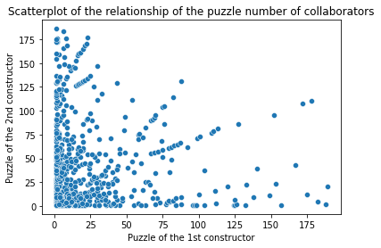

```python
sns.scatterplot(data=collab,x="C1 No.",y="C2 No.")
plt.xlabel("Puzzle of the 1st constructor")
plt.ylabel("Puzzle of the 2nd constructor")
plt.title("Scatterplot of the relationship of the puzzle number of collaborators")
```

There seems to be no correlation between who collaborates with who. However, we can see a clear clustering of points about the x- and y-axes. This suggests that collaborations are mostly used to induct new constructors into the New York Times crossword.

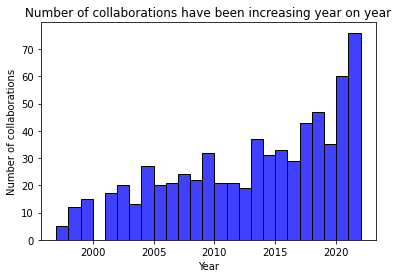

```python
sns.histplot(data=collab,x="Year",color="b",bins=range(1997,2023))
plt.title("Number of collaborations have been increasing year on year")
plt.ylabel("Number of collaborations")
```

While the number of daily crosswords have remained similar throughout the years, the number of collaborations have increased. This suggests more openness within the community to induct new people and a greater sense of community.

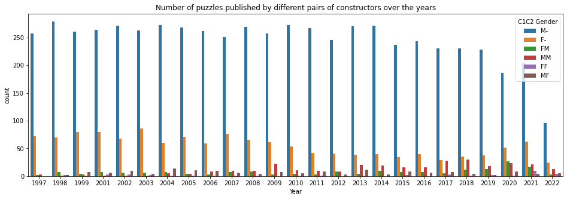

```python
nytData["C1C2 Gender"]=nytData["C1 Gender"].copy()+nytData["C2 Gender"].copy()
plt.figure(figsize=(16,5))
sns.countplot(data=nytData,x="Year",hue="C1C2 Gender")
plt.title("Number of puzzles published by different pairs of constructors over the years")
```

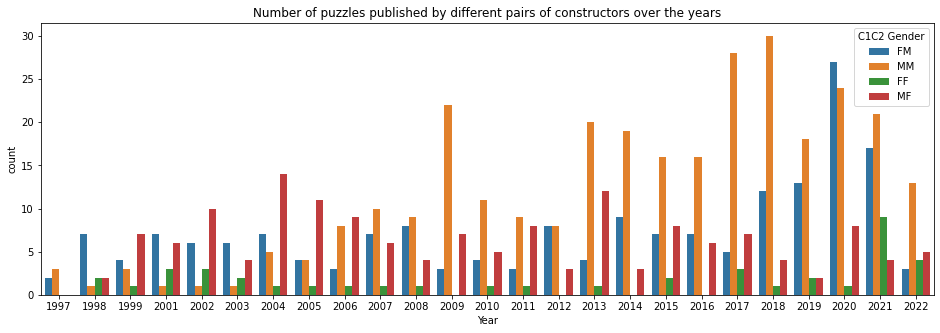

```python
collab["C1C2 Gender"]=collab["C1 Gender"].copy()+collab["C2 Gender"].copy()
plt.figure(figsize=(16,5))
sns.countplot(data=collab,x="Year",hue="C1C2 Gender")
plt.title("Number of puzzles published by different pairs of constructors over the years")
```

No clear trends can be seen between the genders of collaborators.

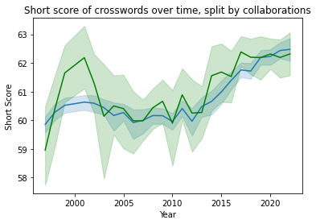

```python
sns.lineplot(data=nytData,x="Year",y="AShort")
sns.lineplot(data=collab,x="Year",y="AShort",color="g")
plt.ylabel("Short Score")
plt.title("Short score of crosswords over time, split by collaborations")
```

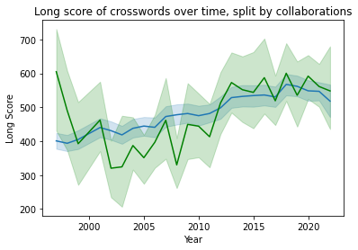

```python
sns.lineplot(data=nytData,x="Year",y="ALong")
sns.lineplot(data=collab,x="Year",y="ALong",color="g")
plt.ylabel("Long Score")
plt.title("Long score of crosswords over time, split by collaborations")
```

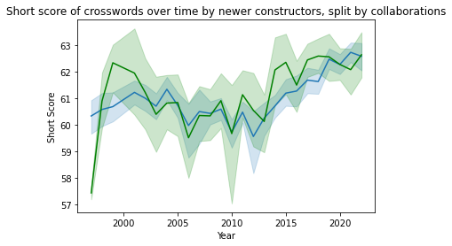

```python
sns.lineplot(data=nytData[(nytData["C1 No."]<10)],x="Year",y="AShort")
sns.lineplot(data=collab[(collab["C1 No."]<10) | (collab["C2 No."]<10)],x="Year",y="AShort",color="g")
plt.ylabel("Short Score")
plt.title("Short score of crosswords over time by newer constructors, split by collaborations")
```

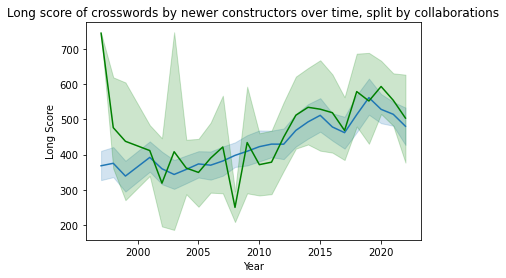

```python
sns.lineplot(data=nytData[(nytData["C1 No."]<10)],x="Year",y="ALong")
sns.lineplot(data=collab[(collab["C1 No."]<10) | (collab["C2 No."]<10)],x="Year",y="ALong",color="g")
plt.ylabel("Long Score")
plt.title("Long score of crosswords by newer constructors over time, split by collaborations")
```

# Results Findings & Conclusion

For each research question, summarize in 2-3 visualizations which will answer the question. Intrepret the results accordingly and give your observation and conclusion. The visualizations should be well presented (apply what you have learnt in Chapter 9 on data communication). The plots shown here could be an enhanced version of the EDA plots, or presented in another format.

For this section, Day 0 refers to Monday, going through the week until Day 6, Sunday.

### Q1: Crosswordese

For this section, I define short score as how "good" entries with 7 letters or less are, using a metric of either the scoring given by wordlist makers, or their frequency on Google NGram. For the score, the higher the better. Remember that crosswordese is defined as the amount of obscure fill. The higher the score, the lower the crosswordese.

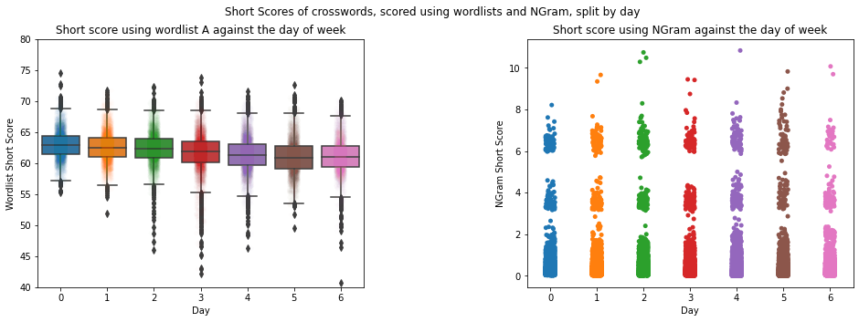

```python
nrow=1
ncol=2

fig = plt.figure(figsize=(16,5))
gs = fig.add_gridspec(nrow, ncol, hspace=0.2, wspace=0.5)
axes = gs.subplots(sharex=True, sharey=False)

sns.stripplot(ax=axes[0],x="Day",y="AAScore",data=short,alpha=0.01)
sns.boxplot(ax=axes[0],x="Day",y="AAScore",data=short)
axes[0].set_title("Short score using wordlist A against the day of week")
axes[0].set_ylim((40,80))
axes[0].set_ylabel("Wordlist Short Score")
sns.stripplot(ax=axes[1],x="Day",y="NNScore",data=short)
axes[1].set_title("Short score using NGram against the day of week")
axes[1].set_ylabel("NGram Short Score")
plt.suptitle("Short Scores of crosswords, scored using wordlists and NGram, split by day")
pass
```

From the wordlist scoring, we can see that the average score of crosswords decreases throughout the week, albeit minimally. This may signal the puzzle being more and more inaccessible to puzzlers, a phenomenon that is caused by editors wishing to cater to the crossword buffs. The wordlist boxplot would show them trying to cater to both newbies and seasoned puzzlers, by making early week puzzles very accessible, and later week ones harder. This is a reasonable compromise by them.

From the NGram score, we can clearly observe that there are three distinct sections in the data. A possible explanation is that it is the fault of the NGram dataset for being more sparse but I suspect that not to be the case. It may be that crosswords are just inaccessible to the general public if they are not within this community, which may explain why crossword scores are higher when the person grading it is a crossword maker themself, and can thus understand the issues. Hence, the wordlist scores are more closely clustered together, as their scoring is rather similar, not deviating by too much, whilst the NGram scores are more far spread since they represent real world use, which is very very different from crosswords.

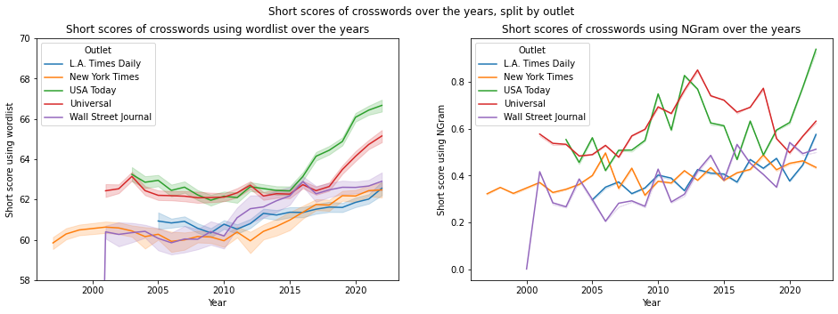

```python
nrow=1
ncol=2

# make a list of all dataframes
fig = plt.figure(figsize=(16,5))
gs = fig.add_gridspec(nrow, ncol, hspace=0.2, wspace=0.2)
axes = gs.subplots(sharex=True, sharey=False)

axes[0].set_ylim((58,70))
sns.lineplot(ax=axes[0],x="Year",y="AAScore",data=short,hue="Outlet")
axes[0].set_ylabel("Short score using wordlist")
axes[0].set_title("Short scores of crosswords using wordlist over the years")
sns.lineplot(ax=axes[1],x="Year",y="NNScore",data=short,hue="Outlet",ci=False)
axes[1].set_ylabel("Short score using NGram")
axes[1].set_title("Short scores of crosswords using NGram over the years")
plt.suptitle("Short scores of crosswords over the years, split by outlet")
```

From the wordlist graph, we can generally infer that, by wordlist standards, all the outlets have their score to be increasing. This graph shows some evidence that the amount of crosswordese has decreased throughout the years. This would mean greater accessibility for the average solver, which knows at least some crosswordese.

From the NGram graph, it seems more erratic, with only USA Today having seen a significant increase. This would suggest a total novice, a person that has never seen a puzzle before, could have a much harder time. A moderate amount of knowledge is needed to break into solving crosswords, but that skill floor has decreased over the years.

The interesting outlier here is USA Today. This outlier is the deliberate action. USA Today crosswords touts themselves as being one of the easier crosswords, being a beginner friendly puzzle. Indeed, it has seem to show that, with a great improvement in accessibility in recent years. This big jump does not imply the superiority over other outlets.

Instead, it showcases a compromise that they have made. Traditionally, crosswords are rotationally or reflectionally symmetrical. However, in recent years, they have given up on symmetry, in favour of better fill and less crosswordese. It can be seen that this method works as a compromise, being less elegant, but being able to induct more solvers into the crossword universe, being an overall positive gain.

### Q2: Freshness

For this section, I define long score as a metric for freshness, the higher the long score, the more fresh the puzzle is. Higher freshness is better.

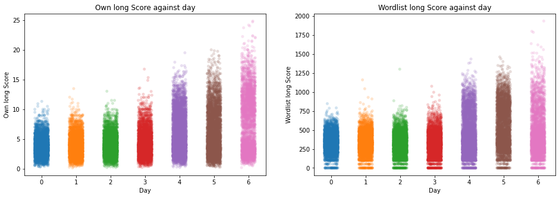

```python
nrow=1
ncol=2

# make a list of all dataframes
fig = plt.figure(figsize=(16,5))
gs = fig.add_gridspec(nrow, ncol, hspace=0.2, wspace=0.2)
axes = gs.subplots(sharex=True, sharey=False)
plt.figure(figsize=(12,5))
sns.stripplot( y="Score", x="Day",  data=long,
                   jitter=0.2, alpha=0.2,ax=axes[0])
axes[0].set_ylabel("Own long Score")
axes[0].set_title("Own long Score against day")
sns.stripplot( y="AScore", x="Day",  data=long,
                   jitter=0.2, alpha=0.2,ax=axes[1])
axes[1].set_ylabel("Wordlist long Score")
axes[1].set_title("Wordlist long Score against day")
plt.suptitle("Long score of crosswords, split by day of week and metric used")
pass
```

As the week goes on, the higher and higher the long score. Obviously, for Sunday puzzles, they will have a higher long score with more grid space. However, for the other days of the week, a different explanation is required. A possible reason is the increasing difficulty of crosswords through the week, especially Friday and Saturday, which are themeless puzzles for some outlets. By being unrestricted from any theme, all their long answers must shine, and there must be more of them, since they have more freedom to grid it. This can be seen using both our own metric and the wordlist, confirming the results. What this means is that, the later week puzzles, even though they are less accessible for newbie solvers, veterans will be satisfied to know that the puzzle is waiting for them with many snazzy answers.

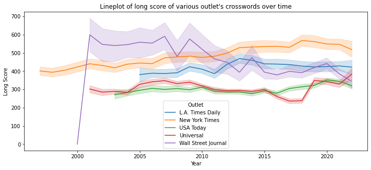

```python
plt.figure(figsize=(12,5))
sns.lineplot(x="Year",y="AScore",data=long,hue="Outlet")
plt.ylabel("Long Score")
plt.title("Lineplot of long score of various outlet's crosswords over time")
```

Based on this line chart alone, we can tell that the New York Times is the best place for fresh fill. This may explain why they are said to be "the gold standard". For some background information, they have the highest rates in the industry, paying about 500USD per puzzle. This potential profit draws many constructors and makes it so the NYT gets more submissions. Then, they have the luxury to prune only the best, which gives them a competitive edge over the other outlets. While most other outlets generally have not seen their freshness change, the New York Times certainly has, as seen here to be above the rest.

The increasing trend is showing that constructors are constantly raising the bar on what they can do and how fresh the puzzles are. We notice that with the rise of computer construction software, it has never been easier to construct crosswords. Trial and error is no longer required, and now constructors can focus solely on making their crossword the best it can be. In my opinion, this graph does reflect such a shift.

Wall Street Journal's decline may be explained by the fact that they have less Sunday crosswords now, which does affect their long score. However, nowadays, it matches with most other outlets.

### Q3: Inclusivity

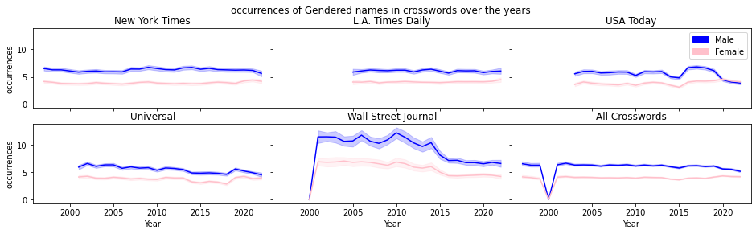

```python
nrow=2
ncol=3

# make a list of all dataframes
fig = plt.figure(figsize=(16,4))
gs = fig.add_gridspec(nrow, ncol, hspace=0.2, wspace=0)
axes = gs.subplots(sharex=True, sharey=True)

# plot counter
import matplotlib.patches as mpatches
outlets=["New York Times","L.A. Times Daily","USA Today","Universal","Wall Street Journal"]
count=0
for r in range(nrow):
    for c in range(ncol):
        if count==5:
            sns.lineplot(ax=axes[1,2],data=names,x="Year",y="BScore",color="b")
            sns.lineplot(ax=axes[1,2],data=names,x="Year",y="GScore",color="pink")
            axes[1,2].set_title("All Crosswords")
        else:
            sns.lineplot(ax=axes[r,c],data=names[names.Outlet==outlets[count]],x="Year",y="BScore",color="b")
            sns.lineplot(ax=axes[r,c],data=names[names.Outlet==outlets[count]],x="Year",y="GScore",color="pink")
            axes[r,c].set_title(outlets[count])
        count+=1
        axes[r,c].set_ylabel("occurrences")
axes[0,2].legend(handles=[mpatches.Patch(color='b'),mpatches.Patch(color='pink')],labels=["Male","Female"])
plt.suptitle("occurrences of Gendered names in crosswords over the years")
```

This graph shows the 5 major outlets and how their occurrences of gendered names have changed throughout the years. New York Times, L.A. Times Daily and Wall Street Journal still use more male names than female names of their crossword, whilst Universal and USA Today seem to be closing the gap. The reason for this change is probably deliberate. At the helm of editors who aim to be more inclusive, these crosswords want to reflect society more fully, trying to get more females to do the puzzle.

Even though its less obvious, the New York Times also seems to be trying to be more inclusive, with a dip in the number of males name used. This may be due to some other factors, which will be discussed in question 4.

On a full scale, the number of gendered names seem to be converging such that there are more female ones and less male ones. This should be celebrated, as it reflects a change in perception in the crossword. Since the crossword somewhat reflects who made the puzzle, the greater similarity in names shows how, the crossword is getting more divrse. No longer is the crossword only for men, but now more people can see themselves in it. That does have an influence on how someone feels, when they see something they identify with rather than a baseball team.

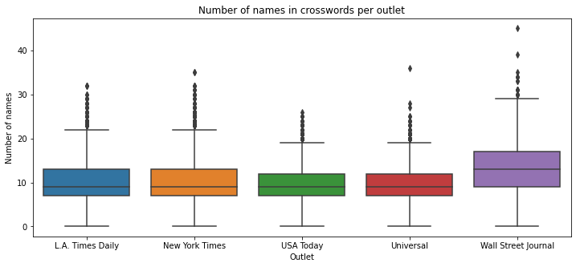

```python
plt.figure(figsize=(12,5))
sns.boxplot(data=names,x="Outlet",y="Total")
plt.ylabel("Number of names")
plt.title("Number of names in crosswords per outlet")
pass
```

It is also interesting to note that, most outlets use generally about the same number of names. However, the clear outlier here is the Wall Street Journal. With more names being used, it may make it harder for someone who does not recognise them to be able to solve the crossword, going back to the issue of crosswordese. Since the number of names being used hovers around 8-9 as a median, even more so from the Wall Street Journal, it is just pertinent that the crosswords contain a diverse set of names, so that no one group of people feel left out. Names are not just another clue, they have the power to make us connect and feel things.

On a side note, it may be that the Wall Street Journal dataset is skewed by the fact that they have more Sunday crosswords, which are bigger, and hence they may contain more names. If this is the case, it probably would not deviate from the general trend of other crosswords too much.

### Q4: Constructors

#### Gender

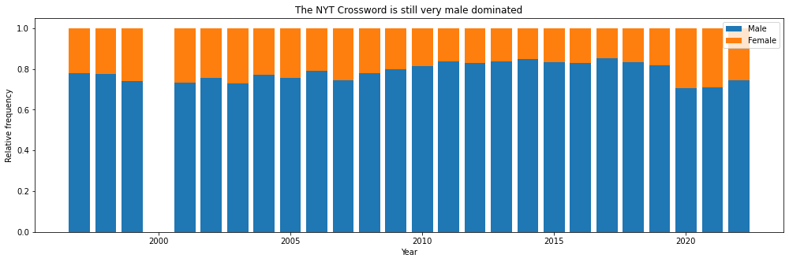

```python
#sns.countplot(data=nytData,x="Year",hue="C1 Gender")
pivot=pd.concat([nytData.groupby("Year")["C1 Gender"].count()
,nytData[(nytData["C1 Gender"]!="F") & (nytData["C2 Gender"]!="F")].groupby("Year")["C1 Gender"].count()
,nytData[(nytData["C1 Gender"]=="F") | (nytData["C2 Gender"]=="F")].groupby("Year")["C1 Gender"].count()],axis=1)
pivot.columns=["Total","Male","Female"]
plt.figure(figsize=(17,5))
plt.bar([x for x in range(1997,2023) if x!=2000], pivot["Male"]/pivot["Total"],  label="Male") #plot the bottom most bar first
plt.bar([x for x in range(1997,2023) if x!=2000], pivot["Female"]/pivot["Total"],  label="Female", bottom=pivot["Male"]/pivot["Total"])
#missing data in 2000
plt.title("The NYT Crossword is still very male dominated")
plt.ylabel("Relative frequency")
plt.xlabel("Year")
plt.legend()
pass
```

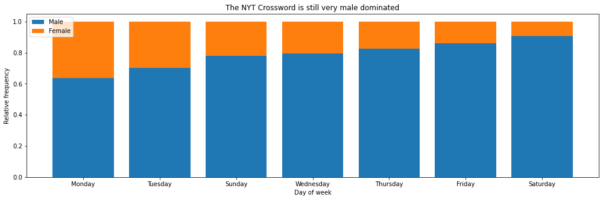

```python
pivot=pd.concat([nytData.groupby("Day")["C1 Gender"].count()
,nytData[(nytData["C1 Gender"]!="F") & (nytData["C2 Gender"]!="F")].groupby("Day")["C1 Gender"].count()
,nytData[(nytData["C1 Gender"]=="F") | (nytData["C2 Gender"]=="F")].groupby("Day")["C1 Gender"].count()],axis=1)
pivot.columns=["Total","Male","Female"]
pivot.sort_values("Male",ascending=True,inplace=True)
plt.figure(figsize=(17,5))
plt.bar(pivot.index, pivot["Male"]/pivot["Total"],  label="Male")
plt.bar(pivot.index, pivot["Female"]/pivot["Total"],  label="Female", bottom=pivot["Male"]/pivot["Total"])
plt.title("The NYT Crossword is still very male dominated")
plt.ylabel("Relative frequency")
plt.xlabel("Day of week")
plt.legend()
pass
```

This first graph shows how the NYT is still very much male-dominated in terms of constructors, even as, since 2020, the number of female constructors are higher than the years before. Most crosswords are still made by male constructors.

The problem is exaserbated when the trend is split by the day of the week. Firstly, notice that the x-axis is generally by the days of the week, except for Sunday. Other than that, since the difficulty of the puzzle increases throughout the week, it is a possible reason why less women construct on those days. As discussed previously, the later days of the week are for crossword buffs, and hence, they may be less inclined to construct for those days, as it is a rather gated community. Earlier days in the week are indeed more accessible to them, which is why they may choose to pick those instead.

This is not to discount them as constructors, however. It may very well be the causes of external factors, like even personal preference that comes down to why they construct those puzzles less. However, it is still a problem, as there is a potential male bias in the fill towards later days, making an already hard puzzle even more inaccessible for a certain gender.

```
(3.0, 8.0)
```

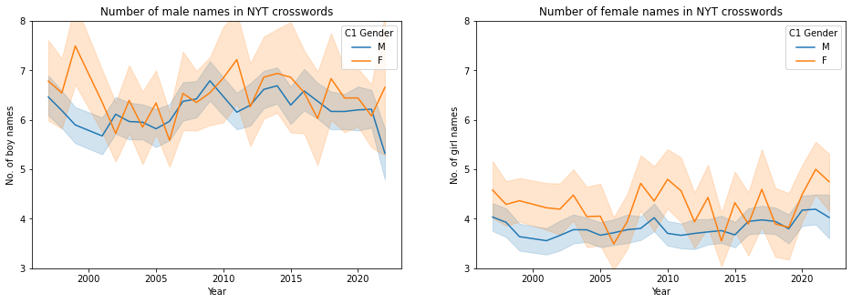

```python
nrow=1
ncol=2

fig = plt.figure(figsize=(16,5))
gs = fig.add_gridspec(nrow, ncol, hspace=0.2, wspace=0.2)
axes = gs.subplots(sharex=True, sharey=False)

sns.lineplot(data=nytData,y="BNames",x="Year",hue="C1 Gender",ax=axes[0])
axes[0].set_ylabel("No. of boy names")
axes[0].set_title("Number of male names in NYT crosswords")
axes[0].set_ylim((3,8))
sns.lineplot(data=nytData,y="GNames",x="Year",hue="C1 Gender",ax=axes[1])
axes[1].set_ylabel("No. of girl names")
axes[1].set_title("Number of female names in NYT crosswords")
axes[1].set_ylim((3,8))
```

This graph illustrates the importance of diversity in construction. Firstly, male names are used more than female names. Since USA Today has shown that more female names can be used, this is not exactly ideal. However, it still shows an important aspect of construction. Female constructors tend to use more female names than male constructors! Since they have grown up as a female, their life experiences and idols and likes would definitely be different. They bring a piece of their personality into the puzzle, incorporating what males may not characterise as common knowledge. While males have been trying to decrease the number of names they use, female constructors have beem capitalising on it, trying to integrate more of their character.

#### Experience

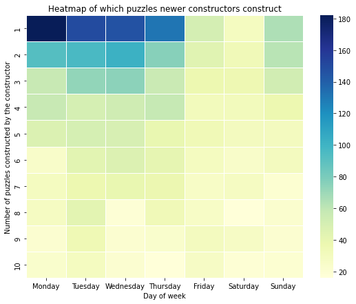

```python
pivot=pd.pivot_table(data=nytData,index="C1 No.",columns="Day",values="Date",aggfunc="count")
pivot.fillna(0,inplace=True)
pivot=pivot.iloc[:10]
plt.figure(figsize=(9,7))
sns.heatmap(pivot[daysOfWeek], cmap="YlGnBu",linewidths=.5)
plt.ylabel("Number of puzzles constructed by the constructor")
plt.xlabel("Day of week")
plt.title("Heatmap of which puzzles newer constructors construct")
pass
```

We can see that as the week goes on, less and less newer constructors make the puzzle. This may be caused by the relative difficulty of constructing such puzzles, which is known to increase through the week. The abnomaly of Sunday can be explained by its difficulty being more simlar to a Wednesday/Thursday puzzle. As the difficulty increases, so will the puzzlemaking difficulty be. Since they are newer constructors, they have a higher chance of being rejected, and so making an early week puzzle is safer. Jeff Chen of XWordInfo, a crossword site, recommends newbies to not dive straight into constructing late-week puzzles. As discussed before, this low density of newer constructors may be caused by NYT being the gold standard, and it being very difficult to be up to the high standards that they have immediately.

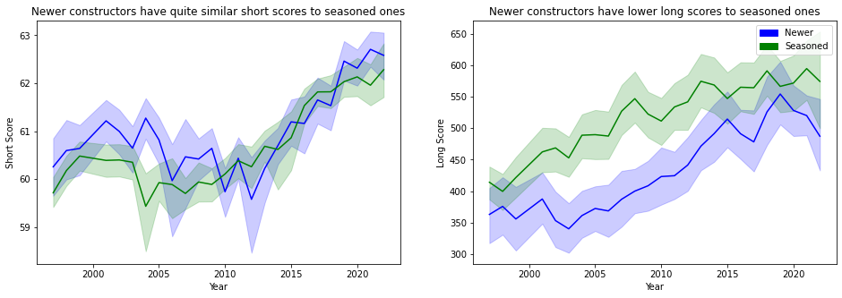

```python
nrow=1
ncol=2

fig = plt.figure(figsize=(16,5))
gs = fig.add_gridspec(nrow, ncol, hspace=0.2, wspace=0.2)
axes = gs.subplots(sharex=True, sharey=False)

plt.figure(figsize=(12,5))
sns.lineplot(ax=axes[1],data=nytData[(nytData["C1 No."]<=10)],x="Year",y="ALong",color="b")
sns.lineplot(ax=axes[1],data=nytData[(nytData["C1 No."]>10)],x="Year",y="ALong",color="g")
axes[1].set_ylabel("Long Score")
axes[1].set_title("Newer constructors have lower long scores to seasoned ones")
sns.lineplot(ax=axes[0],data=nytData[(nytData["C1 No."]<=10)],x="Year",y="AShort",color="b")
sns.lineplot(ax=axes[0],data=nytData[(nytData["C1 No."]>10)],x="Year",y="AShort",color="g")
axes[0].set_ylabel("Short Score")
axes[0].set_title("Newer constructors have quite similar short scores to seasoned ones")
axes[1].legend(handles=[mpatches.Patch(color='b'),mpatches.Patch(color='g')],labels=["Newer","Seasoned"])
pass
```

Newer constructors do have some slight disadvantage when it comes to freshness. But that is to be expected as they are newer to it. These trends are expected and are not surprising. This does justify why its hard for newer constructors to get accepted: they are facing stiff competition. That's not to say that the NYT does not accept them, they still try to aid newer constructors.

#### Collaborations

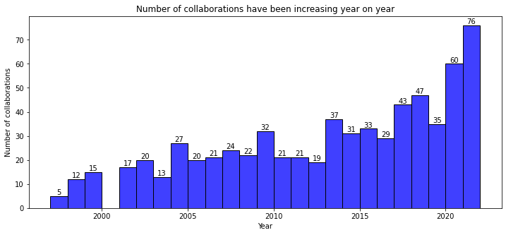

```python
plt.figure(figsize=(12,5))
ax=sns.histplot(data=collab,x="Year",color="b",bins=range(1997,2023))
plt.title("Number of collaborations have been increasing year on year")
plt.ylabel("Number of collaborations")
labels = [str(v) if v else '' for v in ax.containers[0].datavalues]
ax.bar_label(ax.containers[0], labels=labels)
pass
```

As the years have gone by, the number of collaborations have increased. This may be caused by better communication, and the community generally interacting more. More collaborations can benefit everyone. For the constructors, they have a wider range of experiences and can be a more diverse puzzle, being a puzzle for one and all. For solvers, they get to see a more robust puzzle, elevating their solving experience.

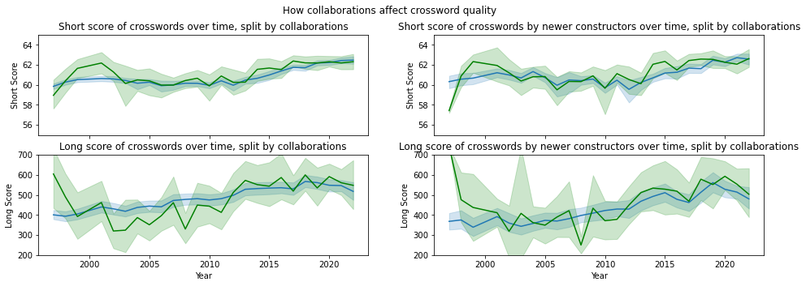

```python
nrow=2
ncol=2

fig = plt.figure(figsize=(16,5))
gs = fig.add_gridspec(nrow, ncol, hspace=0.2, wspace=0.2)
axes = gs.subplots(sharex=True, sharey=False)

sns.lineplot(data=nytData,x="Year",y="AShort",ax=axes[0,0])
sns.lineplot(data=collab,x="Year",y="AShort",color="g",ax=axes[0,0])
axes[0,0].set_ylabel("Short Score")
axes[0,0].set_title("Short score of crosswords over time, split by collaborations")
sns.lineplot(data=nytData,x="Year",y="ALong",ax=axes[1,0])
sns.lineplot(data=collab,x="Year",y="ALong",color="g",ax=axes[1,0])
axes[1,0].set_ylabel("Long Score")
axes[1,0].set_title("Long score of crosswords over time, split by collaborations")
sns.lineplot(data=nytData[(nytData["C1 No."]<10)],x="Year",y="AShort",ax=axes[0,1])
sns.lineplot(data=collab[(collab["C1 No."]<10) | (collab["C2 No."]<10)],x="Year",y="AShort",color="g",ax=axes[0,1])
axes[0,1].set_ylabel("Short Score")
axes[0,1].set_title("Short score of crosswords by newer constructors over time, split by collaborations")
sns.lineplot(data=nytData[(nytData["C1 No."]<10)],x="Year",y="ALong",ax=axes[1,1])
sns.lineplot(data=collab[(collab["C1 No."]<10) | (collab["C2 No."]<10)],x="Year",y="ALong",color="g",ax=axes[1,1])
axes[1,1].set_ylabel("Long Score")
axes[1,1].set_title("Long score of crosswords by newer constructors over time, split by collaborations")
axes[0,0].set_ylim((55,65))
axes[0,1].set_ylim((55,65))
axes[1,0].set_ylim((200,700))
axes[1,1].set_ylim((200,700))
#generating the four corners of the small multiple
plt.suptitle("How collaborations affect crossword quality")
pass
```

# Recommendations or Further Works

State any recommendations, improvements or further works.

Recommendations:

For crosswordese, nothing much can be done about it, it seems pretty much set in stone. For freshness, we can and should try to do better, with the aid of computer programs to aid us. From the current trend, more inclusivity is needed. Various programs provide valuable mentorship to constructors and assist them to debut in a crossword. The most help is required in late week crosswords. More needs to be done, so that a better picture is reflected of who is in our crosswords. Some outlets have been seeing a shift. For example, the L.A. Times Daily has been increasing the publishing of female constructor's puzzles, trying to keep it above 50%. These sort of actions can hopefully induct more marginalised groups into the crosswords, making it a better community. Of course, some outlets simply cannot do that, as with the New York Times. However, they should try their best, to aid some crosswords that are not exactly up to par by more marginalised constructors to give them a chance. Even though this idea is some what unfair, it also serves as some affirmitive action.

Limitations:

This project has largely relied on my own transformed data. Even though I have made best efforts to consider why and how my transformation of data is justified, it still is not perfect. Much data used in this project was transformed from original data sources, so it may be that they are somewhat inaccurate. Having said that however, some of the findings in this project match up largely with what has already been found elsewhere, hence they can generally be considered reliable. One example of this real limitation is how long word scoring using my own scale was rather iffy. Additionally, the only dataset I could find for Q4 was from the New York Times, which may have biased the results and findings, may not apply to other outlets.

Future works

Further exploration can be done on Q4 for the other outlets, as I am missing that data from the other outlets. A more concrete and objective metric can be used, as my methods are not exactly perfect. As more and more crossword types and formats appear, one can try to do a similar project on other variations of the crossword. A famous and interesting example to try this on would be the cryptic crossword, mostly played in the UK.

# Appendix

An appendix is included along with this project, which contains all the web scraping code.

# References

Cite any references made, and links where you obtained the data.

1. https://wordpress.com/support/markdown-quick-reference/ (you may refer to this link on markup for Jupyter when formatting your proposal)
2. https://pudding.cool/2020/11/crossword/ (article that has tried looking at representation before)
3. https://noahveltman.com/crossword/ (project that has tried looking at crosswordese before)
4. https://www.nytimes.com/interactive/2016/02/07/opinion/what-74-years-of-times-crosswords-say-about-the-words-we-use.html (article by the New York Times looking at the evolution of words)

Dataset references

1. https://www.crosswordgiant.com/browse (website to scrape for the clue answer pairs)
2. https://www.xwordinfo.com/ (contains more data about the NYT Crossword in particular)
3. https://books.google.com/ngrams/ (for word searching)
4. https://peterbroda.me/crosswords/wordlist/lists/peter-broda-wordlist__scored.txt (crossword construction wordlist by Peter Broda)
5. https://drive.google.com/uc?export=download&id=1Ruxn8XzRNstU6sDPOMm_K72fVookrPPr (crossword construction wordlist by Brooke Husic and Enrique Henestroza Anguiano)
6. https://www.verywellfamily.com/top-1000-baby-boy-names-2757618 (boy name list)
7. https://www.verywellfamily.com/top-1000-baby-girl-names-2757832 (girl name list)